# Exam Business Analytics

## **Quantile Regression**

**Quantile definition:** $Q_{(p)}= P(Y <Q_{(p)})>p$

Model any quantile as a function of predictive variables: $Q_{(p)}|X=x$

Model a particular quantile $(Q(p))$ of a distribution, given certain values for the covariates $(X = x)$

**Quantiles depiction:**

- They are strictly related to the CDF (cumulative distribution function); By looking at the y-axes (cumulative probability), quantiles are easily identifiable
- Quantile function: x-axes depicts cumulative probability; y-axes depicts the corresponding value for the observed variable ($Q_{(p)}$)

**Empirical Cumulative Distribution Function**: estimator, it is an empirical version of the CDF. For an iid sample it is defined as $\hat{F}_t=\frac{number of observations < t}{n}$

**Sample Quantiles**: sample quantiles are estimated by inverting the ecdf. Then, for a given $p$ estimate $Q(p)$

**Sampling Distribution of Sample Quantiles**: boh

**Quantile as a Minimization Problem**:

F.e. Consider *the median* (the value that divides in two equal parts the dataset). I want to find a $c$ which has on average the lowest absolute distance from the rest of the dataset.

$$Med = argmin E[|Y-c|]$$

More generally we can define any quantile as a minimization problem, where:

$$Q(p)= argmin(d_p(Y,c))$$
and
$$dp(Y, c) =
\left\{
\begin{cases}
(1 - p) |Y - c| & \text{for } Y < c \\
p |Y - c| & \text{for } Y \geq c
\end{cases}
\right.$$

**Quantile based Summary statistics**:

- Scale can be summarised with a quantile-based scale measure (QSC) at a selected $p$: $QSC(p)= Q(1 - p) - Q(p)$ for $p \le 0.5$

IQR is obviously QSC(0.25)

- Skewness can be summarised with a quantile-based skewness or assymetry index

$QSK= \frac{Q(1-p)-Q(0.5)}{Q(0.5)-Q(p)}-1$ for $p \le 0.5$

Obviously, if the distance is not the same than we have skewd data. $QSK >0$ we have right skewness.

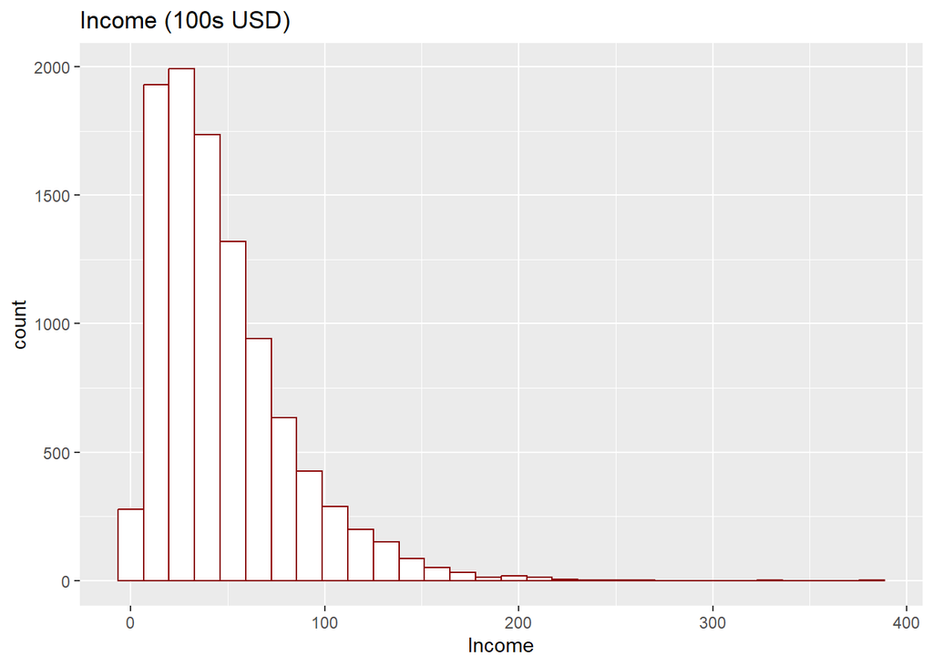

```r
#plot data for income; distribution of income: rightly skewed
incomeEx <- read.table('C:/Users/anton/OneDrive/SKOOL/R/BUSINESS ANALYTICS/DATA/incomeSurvey.csv', header=TRUE,sep=",")
incomeEx$income <- incomeEx$cinc/1000
p1 <- ggplot(incomeEx) +
  geom_histogram(aes(income), col  = "darkred", fill="white") +
  labs(x = "Income", title = "Income (100s USD)")
p1
```

```r
#right skewness: median < mean
mean(incomeEx$income)
```

```
## [1] 47.05639
```

```r
median(incomeEx$income)
```

```
## [1] 39.18834
```

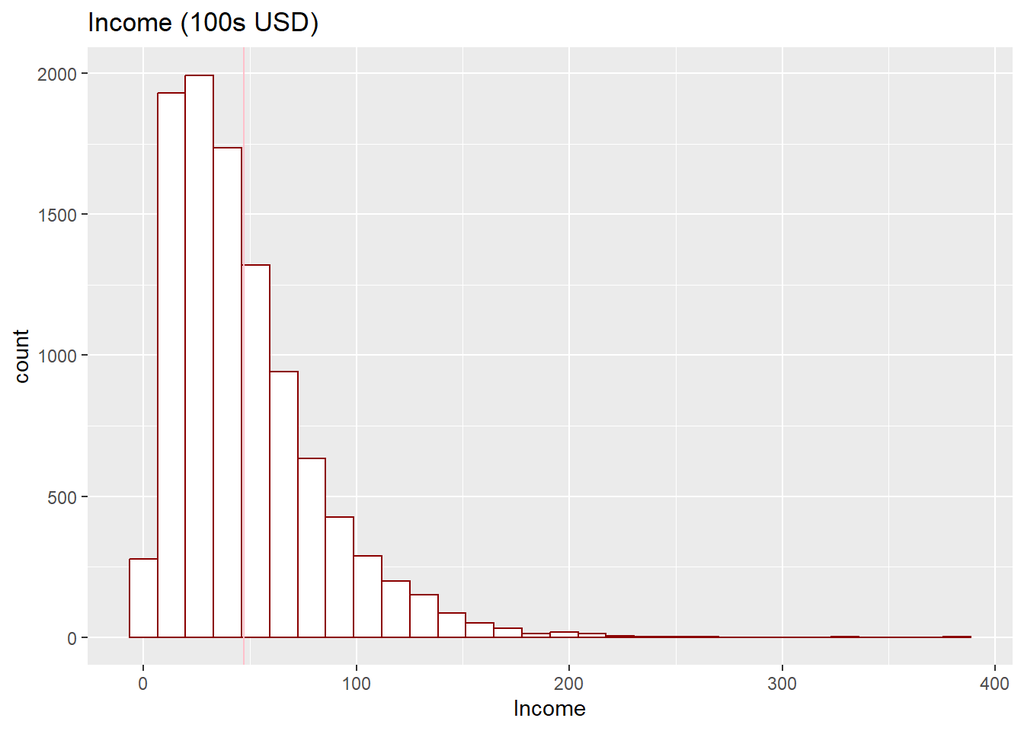

```r
#make it visible
p2 <- ggplot(incomeEx) +
  geom_histogram(aes(income), col  = "darkred", fill="white") +
  labs(x = "Income", title = "Income (100s USD)")+
  geom_vline(xintercept =mean(incomeEx$income), col='pink')+
  geom_vline(xintercept= median(incomeEx$incoem), col='blue')
p2
```

Compute quantiles for the data:

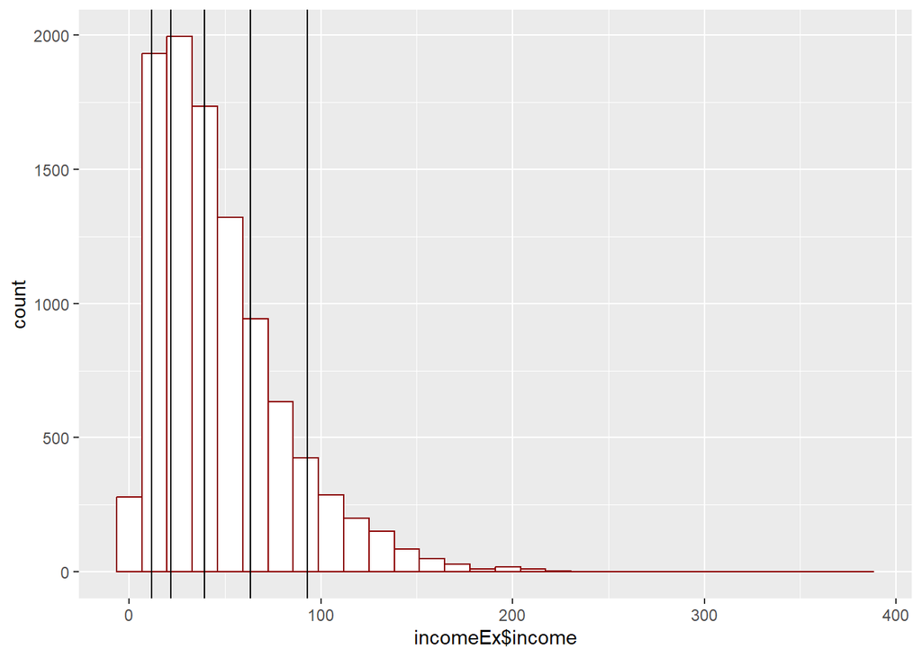

```r
#compute quantiles
pquant<-quantile(incomeEx$income, probs=c(0.1,0.25,0.5,0.75,0.9))

#plot income distribution + quantiles
ggplot()+
  geom_histogram(aes(incomeEx$income), col='darkred',  fill='white')+
  geom_vline(xintercept=pquant)
```

**Note**:

- The distance of 75 quantile from the median is much larger than the distance of the 25q from the median. Indication for assymetry in the distribution of the data;
- We could say that the 25% of the sample earns 21.8663213 or below,meaning this income is exceeded by 75% of the surveyed households; we could say that only 10% of the sample earns above 92.9373906;

Specifically we can also compute the $QSK(.25)$ and $QSK(.1)$. Both these values are positive, indicating right skewness.

```r
#assymetry? yes
#75q - 50q; 50q - 25q
pquant[4]- pquant[3]; pquant[3] - pquant[2]
```

```
##      75%
## 23.96869
```

```
##      50%
## 17.32201
```

```r
#90q - 50q; 50q - 10q
pquant[5]- pquant[3]; pquant[3] - pquant[1]
```

```
##      90%
## 53.74905
```

```
##      50%
## 27.54102
```

```r
#assymetry index:QSK(0.25), QSK(0.1)
qsk_25<- (pquant[4]- pquant[3])/(pquant[3] - pquant[2])-1

qsk_01<-(pquant[5]- pquant[3])/(pquant[3] - pquant[1])-1
```

**Quantiles for known distribution**

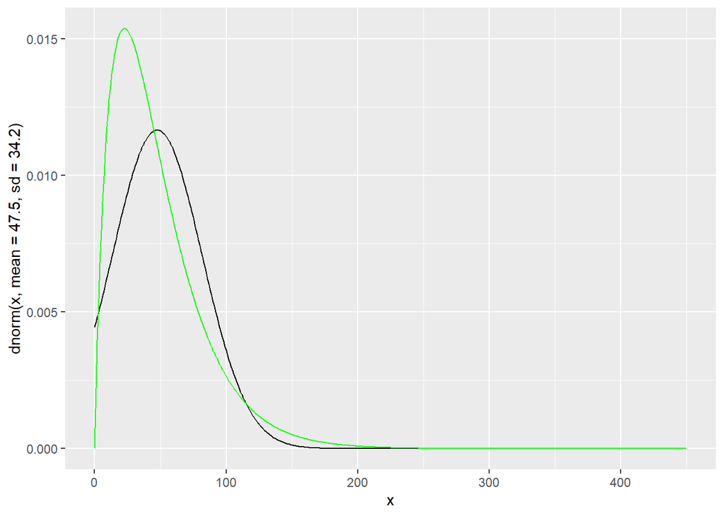

```r
df<-data.frame(x=seq(0,450))

ggplot(df)+
  geom_line(aes(x=x, y=dnorm(x, mean=47.5,sd= 34.2)))+
  geom_line(aes(x=x, y=dgamma(x, 1.9, rate=0.04)), col='green')
```

We compare the values of several key quantiles: notice that the gamma is fairly asymmetric (right-skewed), so $Q(.75) - Q(.50) \neq Q(.50)-Q(.25)$ and $Q(.90) - Q(.50) > Q(.50)-Q(.1)$

```r
pn <- qnorm(c(0.1,0.25,0.5,0.75,0.9), 47, 34.2)
pg <- qgamma(c(0.1,0.25,0.5,0.75,0.9), 1.9, rate = 0.04)
pn[4] - pn[3]; pn[3] - pn[2] #obviously same measures since it is normal
```

```
## [1] 23.06755
```

```
## [1] 23.06755
```

```r
pn[5] - pn[3]; pn[3] - pn[1]
```

```
## [1] 43.82906
```

```
## [1] 43.82906
```

```r
pg[4] - pg[3]; pg[3] - pg[2] #obviously different measures since no normal
```

```
## [1] 24.68976
```

```
## [1] 17.26947
```

```r
pg[5] - pg[3]; pg[3] - pg[1]
```

```
## [1] 54.03003
```

```
## [1] 27.45761
```

Compute the QSK(0.1) value for the two distributions:

```r
(pn[5]-pn[3])/(pn[3]-pn[1]) - 1 ## symmetric
```

```
## [1] -1.110223e-16
```

```r
(pg[5]-pg[3])/(pg[3]-pg[1]) - 1 ## right skewed
```

```
## [1] 0.9677614
```

### The Linear Quantile Regression Model

#### Definition

$$Q^\tau(Y|X)= \beta_{0}^\tau +
\beta_{1}^\tau X$$

- $Q_{\tau}$ of Y is a value, which cumulates a $\tau$ proportion of the dataset;
- $Q_{\tau}(Y|X)$ is the conditional quantile; it must be an estimated line, since we are interested in the value representing the $\tau$ quantile **given** the value of another variable. The $\tau$ quantile probably changes as the predictive variable changes, so we estimate a line ($\beta_0$ and $\beta_1$) to describe these changes on conditional distribution of Y given X for the $\tau$ quantile

#### Estimation

In general QRM estimates for quantile $\tau$ minimise:

$$X_n = \sum_{i=1}^{n} d\tau (y_i, a + b
x_i)$$

where
$$d\tau (y_i, a + b x_i) =
\begin{cases}
(1 - \tau) |y_i - a - b x_i| & \text{for } y_i < a + b x_i \\
\tau |y_i - a - b x_i| & \text{for } y_i \geq a + b x_i
\end{cases}$$

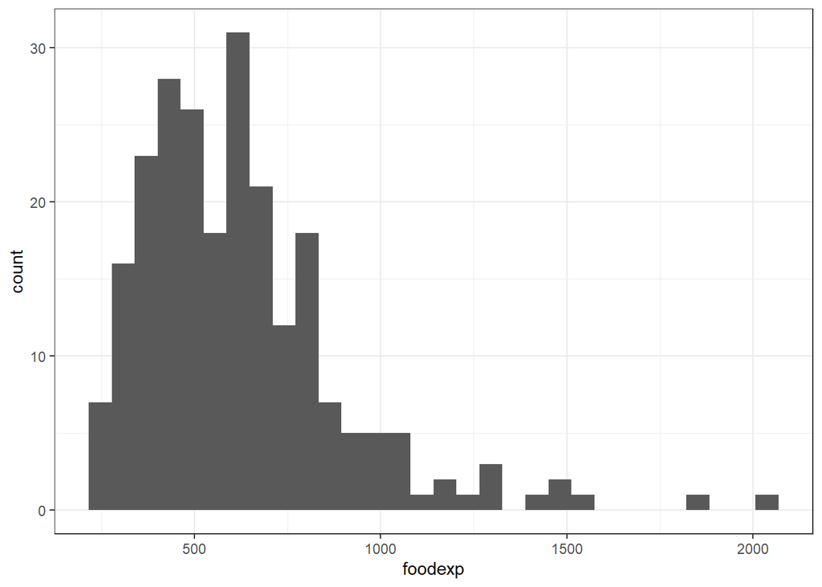

```r
library(dplyr)
library(broom)
library(ggplot2)
theme_set(theme_bw())
library(quantreg)
#load data
data(engel)

#histogram of foodexp
ggplot(data=engel)+
  geom_histogram(aes(foodexp))
```

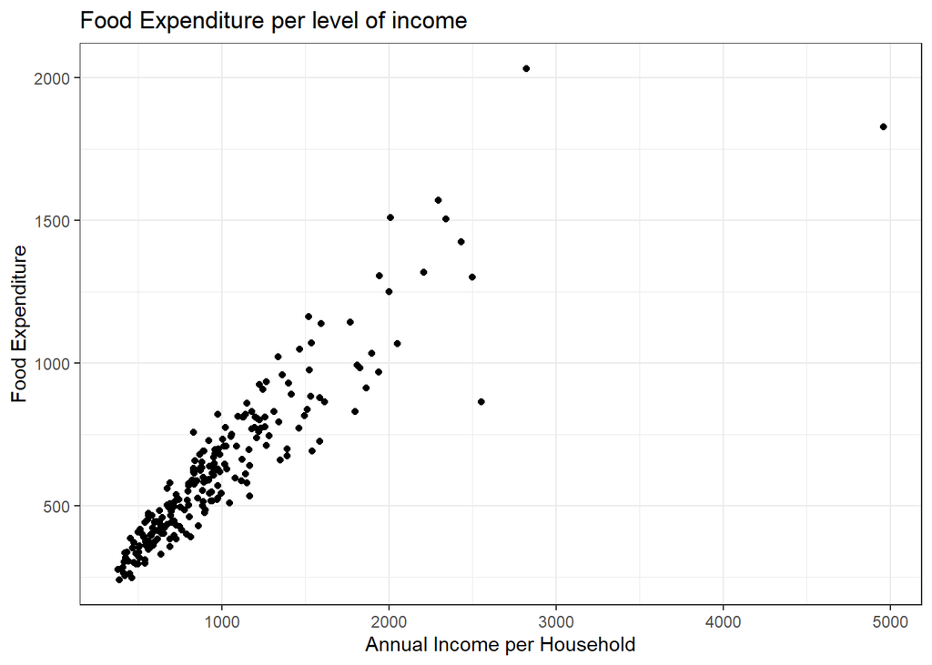

```r
#scatter plot of the data
ggplot(engel)+
  geom_point(aes(income, foodexp))+
  labs(x='Annual Income per Household',
       y='Food Expenditure',
       title= 'Food Expenditure per level of income')
```

To plot the quantile regression we can either use:

- ‘geom_quantile’, which automatically computes the relevant quartiles (you can also specify quantiles with a vector of probabilities)
- compute the model using function ‘rq’. Plot the model using ‘ggplot’ and the ‘augment’ function on the model. add a layer for the line, specifying fitted values grouped by tau as y-values
- compute the model using function ‘rq’. Plot the model using ‘ggplot’ and the function ‘tidy’. Keep in mind you probably need to relaborate the data.frame (wider_pivot). add a layer for the line which takes in slope and intercept (‘geom_abline’)

```
## Smoothing formula not specified. Using: y ~ x
```

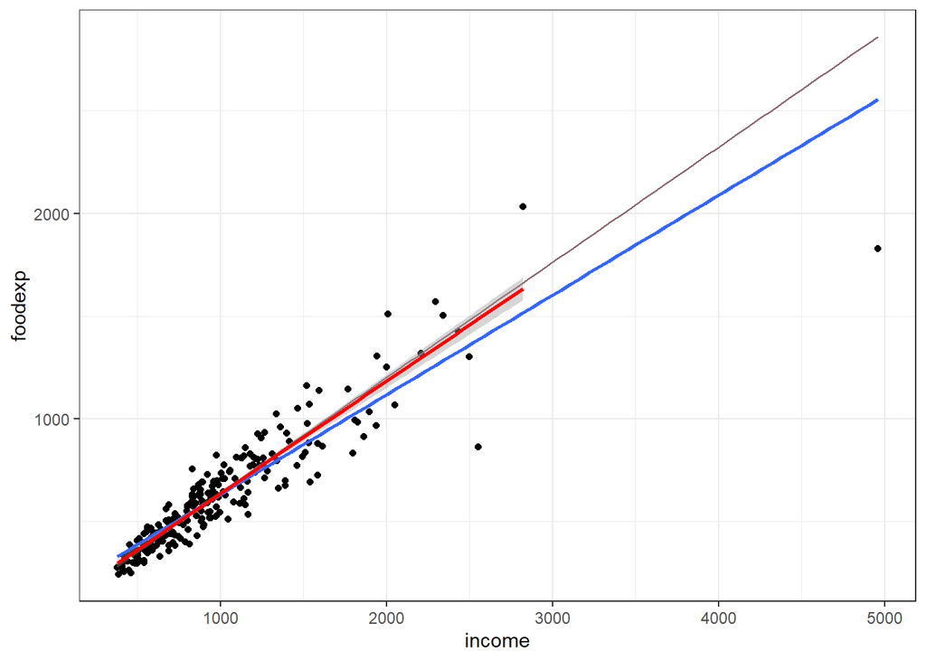

```r
#comparison median regression v. linear regression v. linear reg without outliers
ggplot(engel, aes(income, foodexp))+
  geom_point()+
  geom_quantile(quantiles = 0.5, col='pink4')+
  geom_smooth(method='lm', se=FALSE)+
  geom_smooth(data=engel%>%filter(income<4000), method = 'lm', col='red')
```

**Note**: lm is highly affected by outliers; by removing 1 observation, new model is much more similar to q_median_reg

```
## Smoothing formula not specified. Using: y ~ x
```

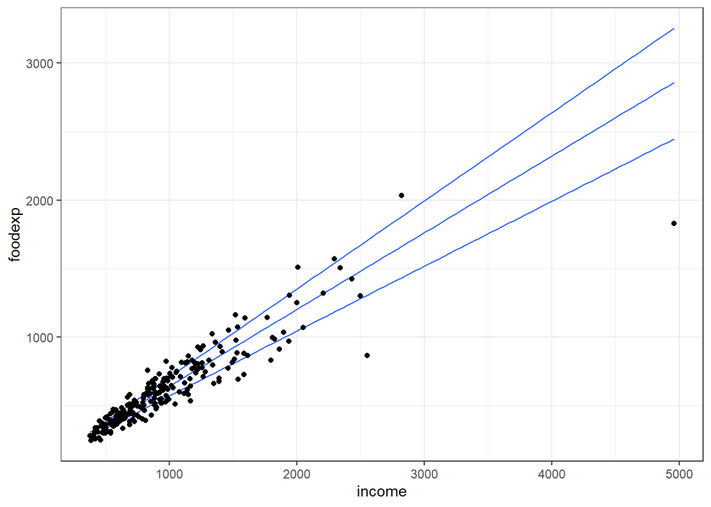

```r
#quantile reg on relevant quartiles (geom_quantile)
ggplot(engel, aes(income, foodexp))+
  geom_quantile()+
  geom_point()
```

```
## Smoothing formula not specified. Using: y ~ x
```

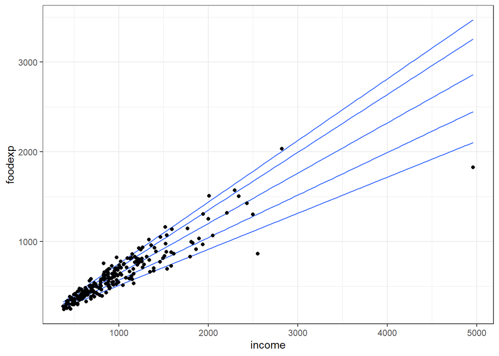

```r
#specify quantiles
ggplot(engel, aes(income, foodexp))+
  geom_quantile(quantiles= c(0.1,0.25,0.5,0.75,0.9))+
  geom_point()
```

**Note**:

- There seems to be an indication that the variability of the distribution is increasing: the range between the *p*th and *(1-p)*th quantile is increasing for various values of *p*.
- The variability we see for food expenditure for lower levels of income is much lower than the variability in food expenditure for higher levels of income.
- There is an indication that families with higher incomes spend more on food expenditure, but for the strength of the relationship becomes steeper for higher quantiles. it means that as you move along the income axis, the corresponding increase in food expenditure becomes more pronounced. steeper strength= the rate at which food expenditure increases for wealthier families is higher compared to less wealthy families.

**Model**

Until now we plotted a quantile regression line. Now we develop the model.

```r
#create model; by default a median regression
rq_engel<-rq(foodexp~income, data = engel)
```

Access information on the model

```r
#coefficinets, lowe bound, upper bound
summary(rq_engel)
```

```
##
## Call: rq(formula = foodexp ~ income, data = engel)
##
## tau: [1] 0.5
##
## Coefficients:
##             coefficients lower bd  upper bd
## (Intercept)  81.48225     53.25915 114.01156
## income        0.56018      0.48702   0.60199
```

```r
#bootstraped-based standard deviation
summary(rq_engel, se='boot')
```

```
##
## Call: rq(formula = foodexp ~ income, data = engel)
##
## tau: [1] 0.5
##
## Coefficients:
##             Value    Std. Error t value  Pr(>|t|)
## (Intercept) 81.48225 24.68330    3.30111  0.00111
## income       0.56018  0.03176   17.64039  0.00000
```

```r
#estimate, lower bound, upper bound, tau; you can also bootstrap
#Intercept:It is the predicted median food expenditure when all predictor variables are zero
#Income:The estimate for income represents the estimated change in the median food expenditure for a one-unit increase in income, holding all other variables constant
rq_engel%>%tidy()
```

```
## # A tibble: 2 × 5
##   term        estimate conf.low conf.high   tau
##   <chr>          <dbl>    <dbl>     <dbl> <dbl>
## 1 (Intercept)   81.5     47.1     135.      0.5
## 2 income         0.560    0.480     0.613   0.5
```

```r
rq_engel%>%tidy(se='boot')
```

```
## # A tibble: 2 × 6
##   term        estimate std.error statistic p.value   tau
##   <chr>          <dbl>     <dbl>     <dbl>   <dbl> <dbl>
## 1 (Intercept)   81.5     29.8         2.73 0.00679   0.5
## 2 income         0.560    0.0382     14.7  0         0.5
```

```r
#glance()
rq_engel%>%glance()
```

```
## # A tibble: 1 × 5
##     tau logLik     AIC   BIC df.residual
##   <dbl> <logLik> <dbl> <dbl>       <int>
## 1   0.5 -1411.63 2827. 2834.         233
```

```r
#augment() -> x,y, fitted, tau and res; suitable for plots
rq_engel%>%augment()
```

```
## # A tibble: 235 × 5
##    foodexp income  .resid .fitted  .tau
##      <dbl>  <dbl>   <dbl>   <dbl> <dbl>
##  1    256.   420.  -61.0     317.   0.5
##  2    311.   541.  -73.8     385.   0.5
##  3    486.   901. -101.      586.   0.5
##  4    403.   639.  -36.5     439.   0.5
##  5    496.   751.   -6.55    502.   0.5
##  6    634.   946.   22.5     611.   0.5
##  7    631.   829.   84.7     546.   0.5
##  8    700.   979.   70.4     630.   0.5
##  9    831.  1310.   15.7     815.   0.5
## 10    815.  1492. -102.      917.   0.5
## # ℹ 225 more rows
```

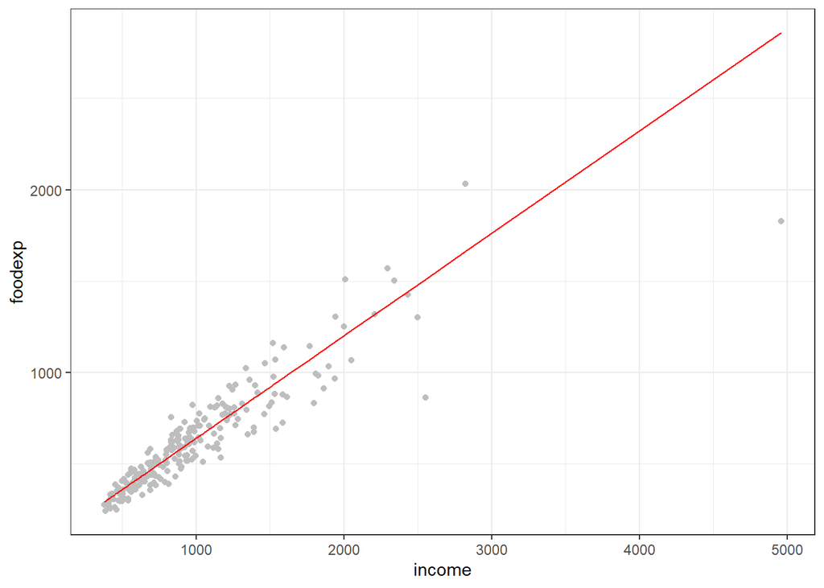

```r
#example for augment + ggplot

ggplot(data=rq_engel%>%augment())+
  geom_point(aes(income, foodexp), col='grey')+
  geom_line(aes(income,.fitted), col='red')
```

We could also want to estimate a quantile regression model for several quantiles: this can be done with a unique call using the option `tau`:

```r
mult_rq_engel<-rq(foodexp~income, data=engel, tau=c(0.1,0.25,0.5,0.75,0.9))

mult_rq_engel%>%tidy()
```

```
## # A tibble: 10 × 5
##    term        estimate conf.low conf.high   tau
##    <chr>          <dbl>    <dbl>     <dbl> <dbl>
##  1 (Intercept)  110.      74.7     152.     0.1
##  2 income         0.402    0.340     0.454  0.1
##  3 (Intercept)   95.5     67.6     135.     0.25
##  4 income         0.474    0.417     0.511  0.25
##  5 (Intercept)   81.5     47.1     135.     0.5
##  6 income         0.560    0.480     0.613  0.5
##  7 (Intercept)   62.4     27.8     120.     0.75
##  8 income         0.644    0.574     0.705  0.75
##  9 (Intercept)   67.4     34.5     115.     0.9
## 10 income         0.686    0.641     0.743  0.9
```

```r
mult_rq_engel%>%augment()
```

```
## # A tibble: 1,175 × 5
##    foodexp income .tau  .resid .fitted
##      <dbl>  <dbl> <chr>  <dbl>   <dbl>
##  1    256.   420. 0.1    -23.1    279.
##  2    256.   420. 0.25   -38.8    295.
##  3    256.   420. 0.5    -61.0    317.
##  4    256.   420. 0.75   -77.1    333.
##  5    256.   420. 0.9    -99.9    356.
##  6    311.   541. 0.1    -16.7    328.
##  7    311.   541. 0.25   -41.2    352.
##  8    311.   541. 0.5    -73.8    385.
##  9    311.   541. 0.75  -100.     411.
## 10    311.   541. 0.9   -128.     439.
## # ℹ 1,165 more rows
```

Second and third option for plotting quantile regression:

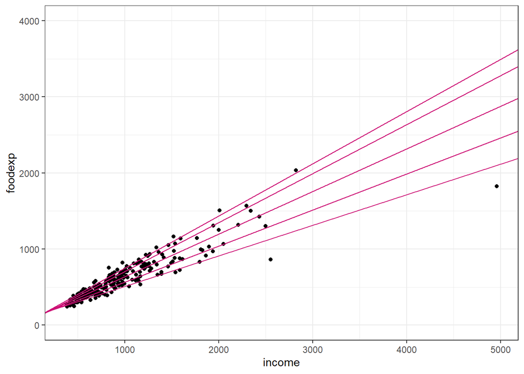

```r
library(tidyr)

# 2) plot multiple qr: use estimated intercepts/slopes (geom_abline)
#opposite of pivot_longer
widedf <- mult_rq_engel %>% tidy(se.type = "boot") %>%
  select(term, estimate, tau) %>%
  pivot_wider(names_from = term, values_from = estimate)

ggplot() +
  geom_point(data = engel, aes(income, foodexp)) +
  geom_abline(data = widedf, aes(slope = income,
                                 intercept = `(Intercept)`),
              col ="deeppink3")  + ylim(0,4000)
```

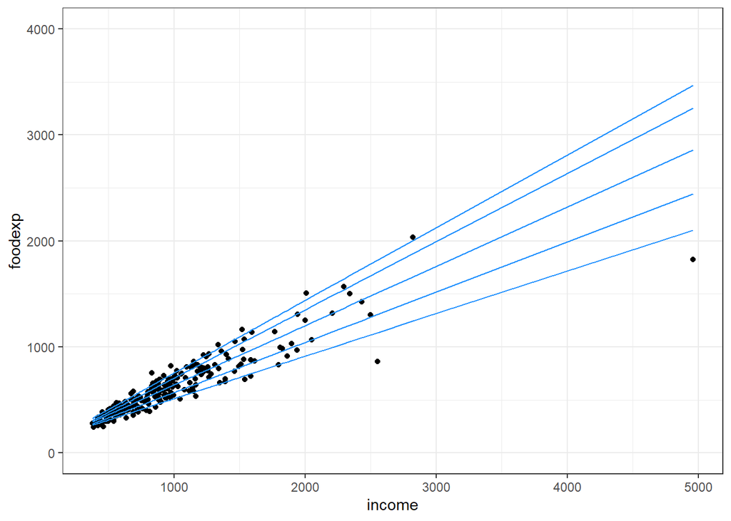

```r
#3) plot multiple qr: augment() and group by tau
aug1 <- mult_rq_engel %>% augment()
ggplot() +
  geom_point(data = engel, aes(income, foodexp)) +
  geom_line(data = aug1, aes(income, .fitted, group = .tau),
            col = "dodgerblue")  + ylim(0,4000)
```

```r
mult_rq_engel %>% augment(newdata = data.frame(income = c(3000, 8000)))
```

```
## # A tibble: 10 × 3
##    income .tau  .fitted
##     <dbl> <chr>   <dbl>
##  1   3000 0.1     1315.
##  2   3000 0.25    1518.
##  3   3000 0.5     1762.
##  4   3000 0.75    1994.
##  5   3000 0.9     2126.
##  6   8000 0.1     3324.
##  7   8000 0.25    3888.
##  8   8000 0.5     4563.
##  9   8000 0.75    5215.
## 10   8000 0.9     5558.
```

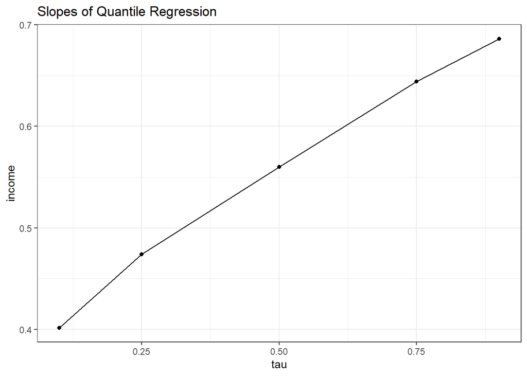

```r
#plot slopes as a function of tau; slopes increase as tau increases
mult_rq_engel%>%
  tidy(se='boot')%>%
  select(term,tau, estimate)%>%
  pivot_wider(names_from=term,values_from =estimate )%>%
  ggplot(aes(tau, income))+
  geom_line()+
  geom_point()+
  labs(title= 'Slopes of Quantile Regression')
```

Let’s now see what the predicted values look like:

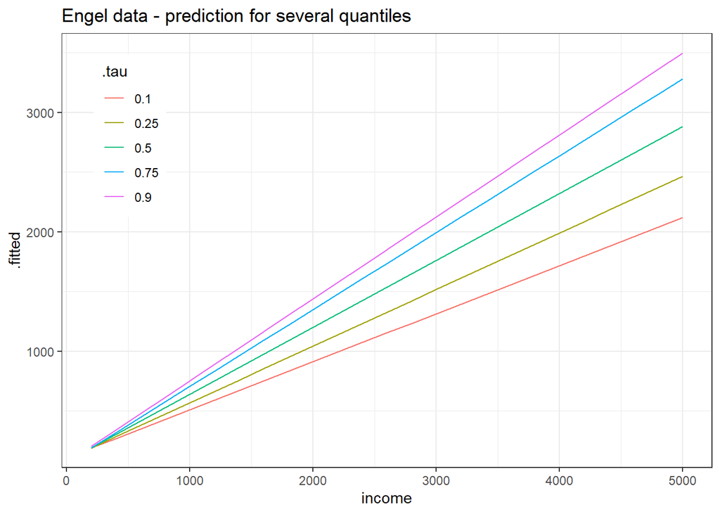

```r
#1)create new dataset for predictions
pred_df <- tibble(income = seq(200, 5000, by = 200))

#use augment(newdata=); apply model to new data
pred_df <- mult_rq_engel%>% augment(newdata = pred_df)
#order data; plot predicted
ggplot(pred_df[order(pred_df$income),]) +
  geom_line(aes(income, .fitted, col = .tau)) +
  labs(title = "Engel data - prediction for several quantiles") +
  theme(legend.position = c(0.05,0.95), legend.justification = c(0,1))
```

```r
#2) model applied for specific values of the income variable
mult_rq_engel %>% augment(newdata = tibble(income = c(3500, 4000)))
```

```
## # A tibble: 10 × 3
##    income .tau  .fitted
##     <dbl> <chr>   <dbl>
##  1   3500 0.1     1516.
##  2   3500 0.25    1755.
##  3   3500 0.5     2042.
##  4   3500 0.75    2316.
##  5   3500 0.9     2469.
##  6   4000 0.1     1717.
##  7   4000 0.25    1992.
##  8   4000 0.5     2322.
##  9   4000 0.75    2638.
## 10   4000 0.9     2813.
```

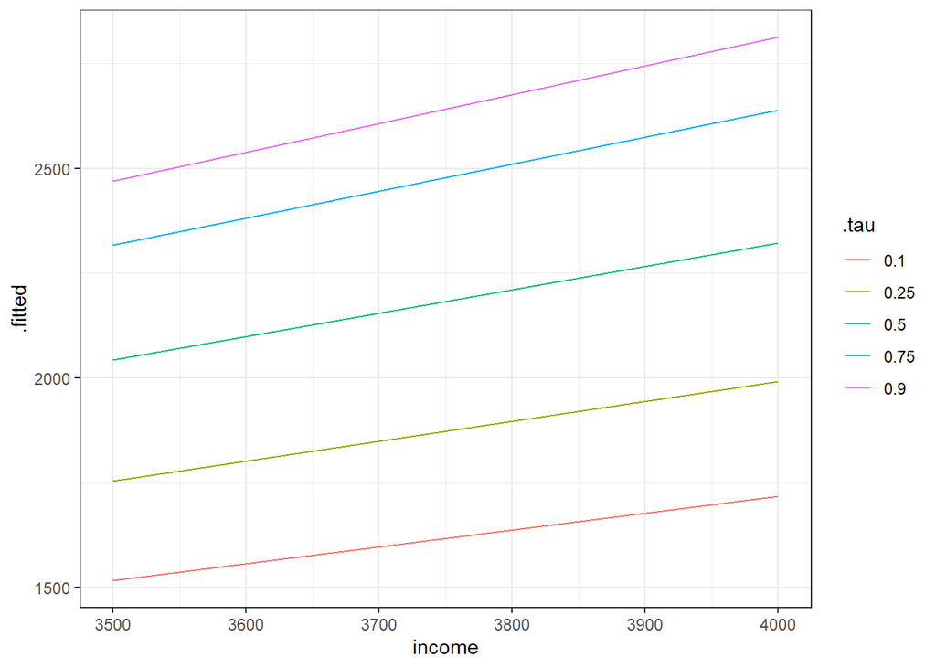

```r
ggplot()+
  geom_line(data= mult_rq_engel%>%augment(newdata=tibble(income=c(3500,4000))),
            aes(income, .fitted, col=.tau))
```

**Equality of slopes testing**: test (making inference) on whether the slopes for the quantile regression on different $\tau$s are the same. If that is the case the difference on the regression lines would be a constant and we could assume conditionally identically distributed response variable.

$$H_0: \beta_{1}^{(\tau_1)} = \ldots =
\beta_{1}^{(\tau_q)} \quad \text{against}
\quad H_1: \beta_{1}^{(\tau_1)} \neq \ldots \neq
\beta_{1}^{(\tau_d)}$$

```r
anova(mult_rq_engel)
```

```
## Quantile Regression Analysis of Deviance Table
##
## Model: foodexp ~ income
## Joint Test of Equality of Slopes: tau in {  0.1 0.25 0.5 0.75 0.9  }
##
##   Df Resid Df F value    Pr(>F)
## 1  4     1171  11.466 3.927e-09 ***
## ---
## Signif. codes:  0 '***' 0.001 '**' 0.01 '*' 0.05 '.' 0.1 ' ' 1
```

The F-value is statistically significant meaning we can reject the null hypothesis of equality of slopes. This is coherent with what we observed before, slopes changed as $\tau$ changed.

### The quantile regression with multiple explanatory variables

**Definition**:

$$Q_{\tau}(Y|X_1,...X_d)=
\beta^{\tau}_0+\beta^{\tau}_1x_1i.....+\beta^{\tau}_dx_di+\epsilon^{\tau}_j$$

where:

- X is a matrix of $d+1$ columns and as many rows as the observations of the dataset
- $\beta^{\tau}$ is a vector containing as $d+1$ estimates (not $d$ because of the intercept $\beta_0$)
- Interpretation of $\beta_j$: the effect of $x_j$ on the quantile $\tau$ as the effect of other variables is considered;

**Estimation of the model**

Does the addition of $X_j$ improve the goodness of fit? Are they relevant?

How can we make inference? **Bootstrap**

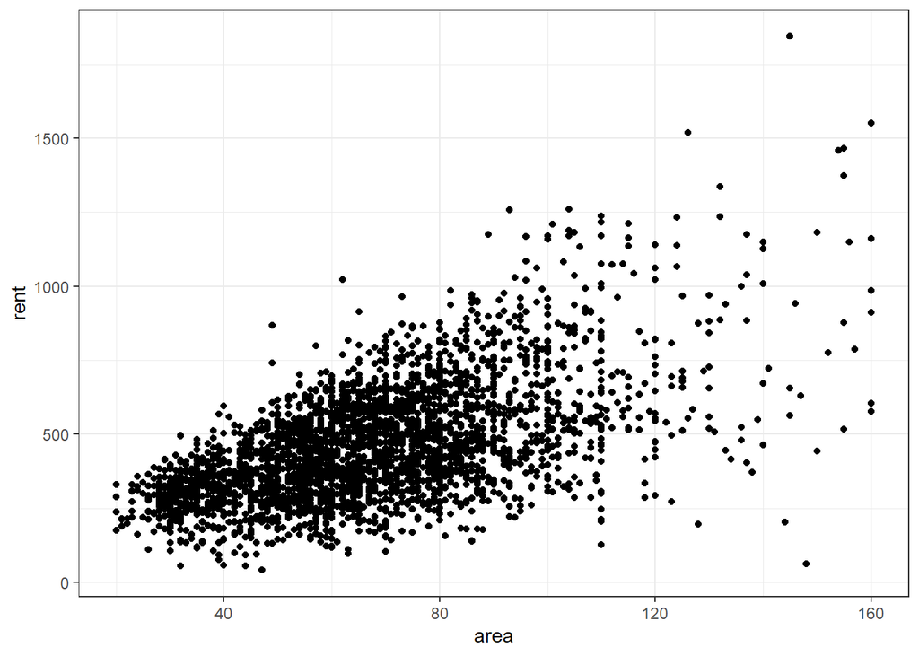

```r
rents<-read.table("C:/Users/anton/OneDrive/SKOOL/R/BUSINESS ANALYTICS/DATA/rent99.raw", header=TRUE)

ggplot(rents) + geom_point(aes(area, rent)) #strong increase in rent as area increases
```

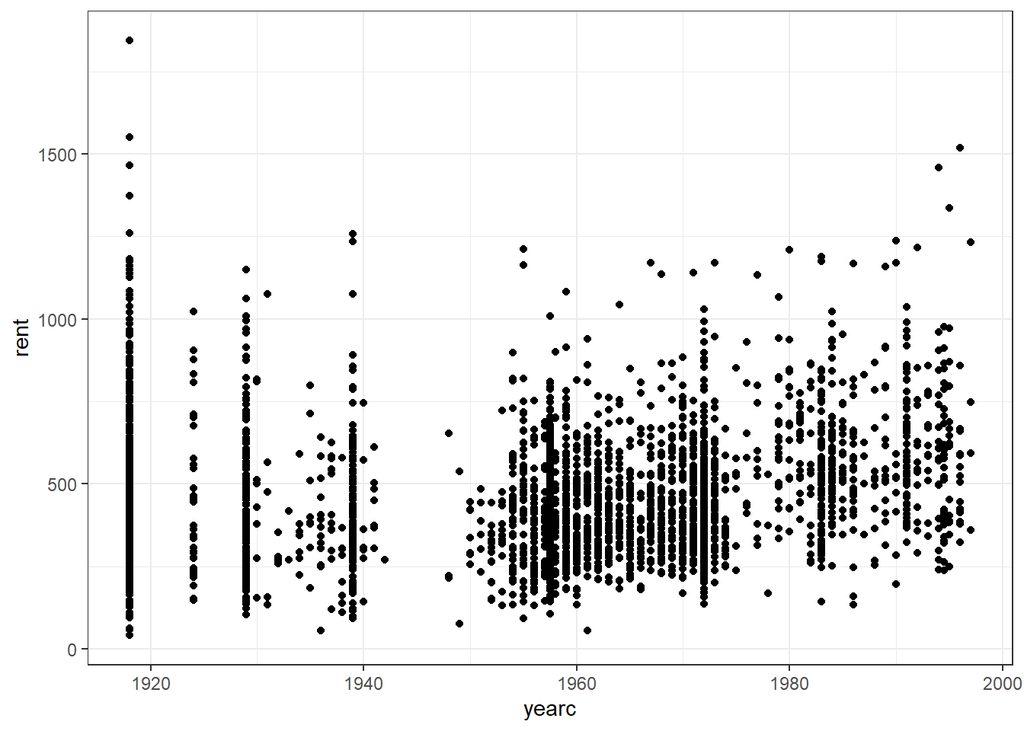

```r
ggplot(rents) + geom_point(aes(yearc, rent)) #not so evident increasing trend over time
```

Dataset: - rent: net rent per month (euros)

- rentsqm: net rent per month per square meter (euros)
- area Living area (square meters)
- year: year of construction
- location: as judged by an expert coded as 1=average location; 2: good location; 3= top location
- bath: quality of the bathroom 0: standard; 1: premium
- kitchen: quality of the kitchen 0: standard; 1: premium
- cheating: presence of central heating 0: without; 1: with district: district in Munich

```r
#include area and year as predictors for rent
library(quantreg)
rqfit_munich <- rq(rent ~ area+yearc,
                   data = rents,
                   tau = c(0.1,0.25,0.5,0.75,0.9))
#visualize model
summary(rqfit_munich)
```

```
##
## Call: rq(formula = rent ~ area + yearc, tau = c(0.1, 0.25, 0.5, 0.75,
##     0.9), data = rents)
##
## tau: [1] 0.1
##
## Coefficients:
##             Value       Std. Error  t value     Pr(>|t|)
## (Intercept) -5058.80330   324.83578   -15.57342     0.00000
## area            3.05560     0.17113    17.85585     0.00000
## yearc           2.63050     0.16536    15.90769     0.00000
##
## Call: rq(formula = rent ~ area + yearc, tau = c(0.1, 0.25, 0.5, 0.75,
##     0.9), data = rents)
##
## tau: [1] 0.25
##
## Coefficients:
##             Value       Std. Error  t value     Pr(>|t|)
## (Intercept) -5169.02146   218.11192   -23.69894     0.00000
## area            3.73253     0.11740    31.79363     0.00000
## yearc           2.69683     0.11101    24.29254     0.00000
##
## Call: rq(formula = rent ~ area + yearc, tau = c(0.1, 0.25, 0.5, 0.75,
##     0.9), data = rents)
##
## tau: [1] 0.5
##
## Coefficients:
##             Value       Std. Error  t value     Pr(>|t|)
## (Intercept) -5799.91793   287.48210   -20.17488     0.00000
## area            4.97688     0.14688    33.88284     0.00000
## yearc           3.02031     0.14599    20.68795     0.00000
##
## Call: rq(formula = rent ~ area + yearc, tau = c(0.1, 0.25, 0.5, 0.75,
##     0.9), data = rents)
##
## tau: [1] 0.75
##
## Coefficients:
##             Value       Std. Error  t value     Pr(>|t|)
## (Intercept) -4314.46052   263.07282   -16.40025     0.00000
## area            6.46672     0.15982    40.46359     0.00000
## yearc           2.26556     0.13086    17.31327     0.00000
##
## Call: rq(formula = rent ~ area + yearc, tau = c(0.1, 0.25, 0.5, 0.75,
##     0.9), data = rents)
##
## tau: [1] 0.9
##
## Coefficients:
##             Value       Std. Error  t value     Pr(>|t|)
## (Intercept) -3006.25375   373.11973    -8.05708     0.00000
## area            8.17531     0.19492    41.94277     0.00000
## yearc           1.58762     0.18963     8.37226     0.00000
```

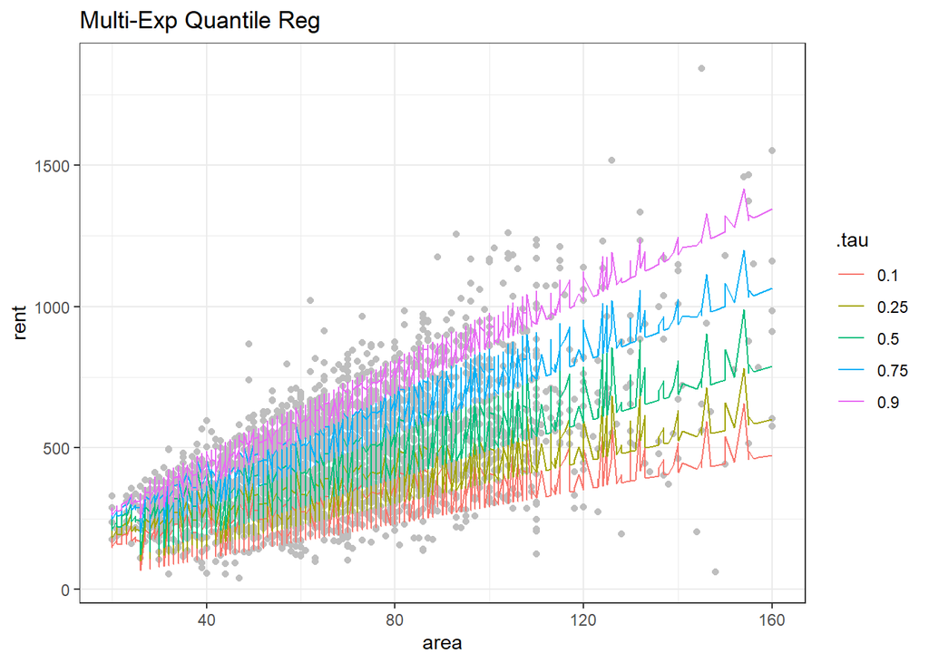

```r
#wrong plot: we have 2 explanatory variables
pred_df <- rqfit_munich %>%
  augment()

ggplot(pred_df)+
  geom_point(aes(area,rent), col='grey')+
  geom_line(aes(area, .fitted,col=.tau))+
  labs(title = 'Multi-Exp Quantile Reg',
       xlab='Area (sqmt)',
       ylab='Rent (euros)')
```

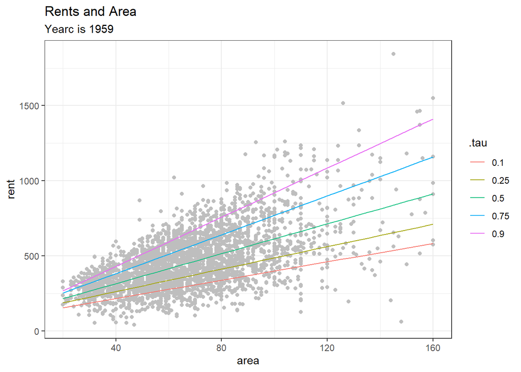

```r
#SOLUTION: FIX THE VALUE FOR ONE OF THE EXPLANATORY VARIABLES
#create a tibble with the values of area (summary(rents$area), get min and max),
#and then fix the value for year (summary(rents$yearc) look for the median)


#plot rent v. area (fixed year)
pred_df<-rqfit_munich%>%
  augment(newdata=tibble(area=seq(20,160, by=5), yearc=1959))

ggplot(data=pred_df)+
  geom_point( data=rents,aes(area, rent), col='grey')+
  geom_line(aes(area, .fitted, col=.tau ))+
  labs(title = 'Rents and Area',
       subtitle = 'Yearc is 1959')
```

```r
#questa è la regressione quantile multipla per i quantili rilevanti, con variabile predittive anno e area,
#e la rappresentazione del modello
```

```r
#fix area and plot rents v. year (fixed area)

summary(rents$area)
```

```
##    Min. 1st Qu.  Median    Mean 3rd Qu.    Max.
##   20.00   51.00   65.00   67.37   81.00  160.00
```

```r
summary(rents$yearc)
```

```
##    Min. 1st Qu.  Median    Mean 3rd Qu.    Max.
##    1918    1939    1959    1956    1972    1997
```

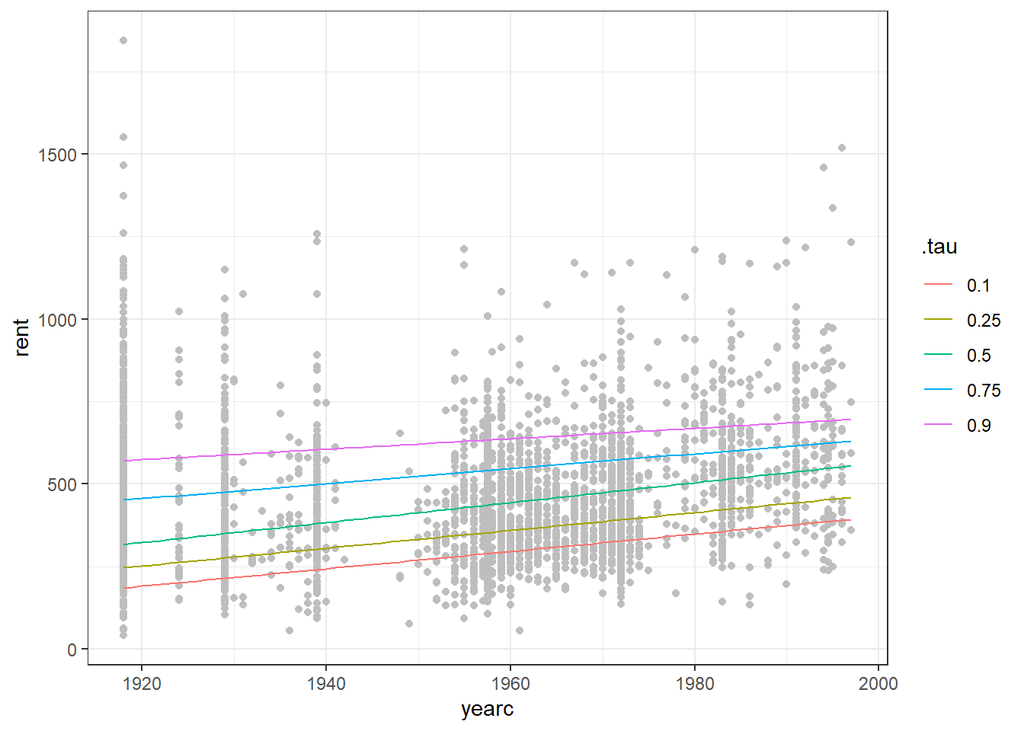

```r
pred_df<-rqfit_munich%>%
  augment(newdata=tibble(area=65, yearc=seq(1918,1997, by=1)))

ggplot()+
  geom_point(data=rents, aes(yearc, rent), col='grey')+
  geom_line(data=pred_df, aes(yearc, .fitted, col= .tau))
```

Let’s look at the residuals:

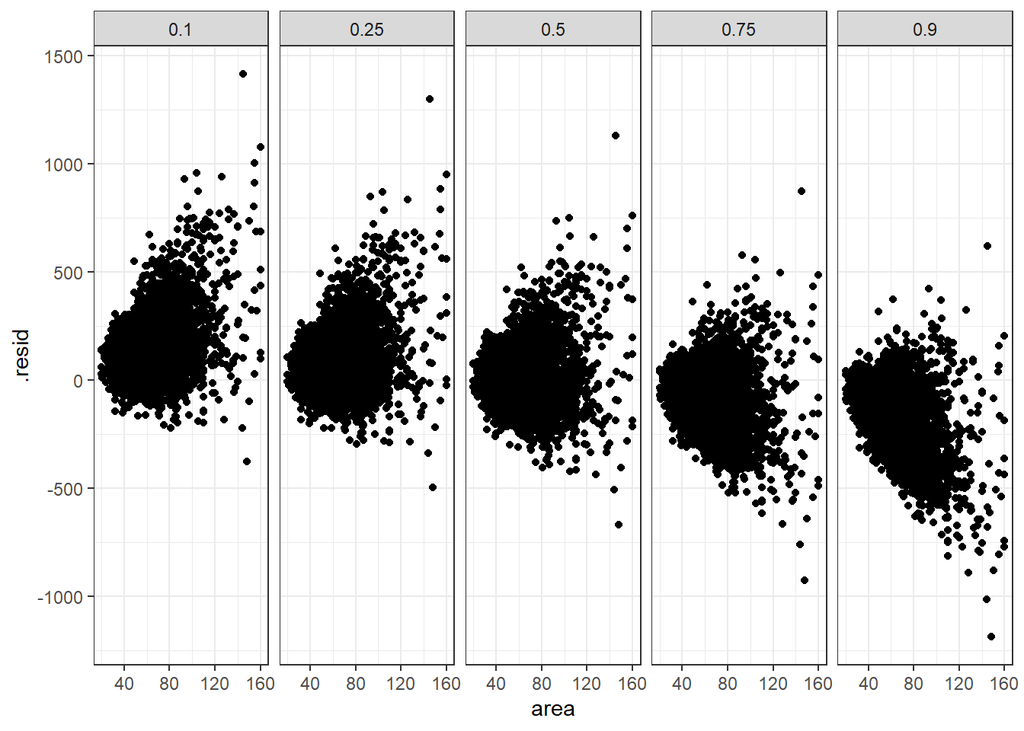

```r
#plot residuals (recall residuals = obs- fitted) ;
library(broom)

#area: per tutti i quantili all'aumentare dell'area, la variabilità dei residuals aumenta
rqfit_munich %>% augment() %>%
  ggplot(aes(area, .resid)) + geom_point() +
  facet_grid(~.tau)
```

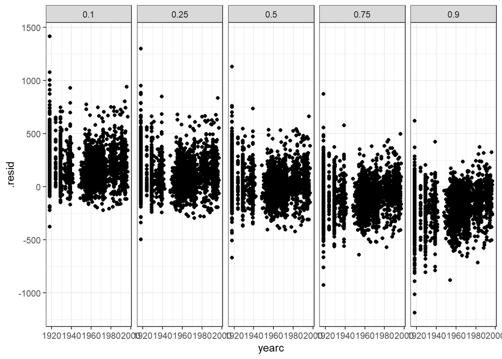

```r
#year
rqfit_munich %>% augment() %>%
  ggplot(aes(yearc, .resid)) + geom_point() +
  facet_grid(~.tau)
```

**More complex model fit**

```r
rqfit2_munich <- rq(rent ~ area+yearc+I(area^2)+I(yearc^2),
                   data = rents,
                   tau = c(0.1,0.25,0.5,0.75,0.9))

#visualize dataset
rqfit2_munich%>%augment()
```

```
## # A tibble: 15,410 × 8
##     rent  area yearc `I(area^2)` `I(yearc^2)` .tau   .resid .fitted
##    <dbl> <int> <dbl>    <I<dbl>>     <I<dbl>> <chr>   <dbl>   <dbl>
##  1  121.    35  1939        1225      3759721 0.1    -28.5     149.
##  2  121.    35  1939        1225      3759721 0.25   -57.0     178.
##  3  121.    35  1939        1225      3759721 0.5   -103.      224.
##  4  121.    35  1939        1225      3759721 0.75  -184.      305.
##  5  121.    35  1939        1225      3759721 0.9   -233.      354.
##  6  437.   104  1939       10816      3759721 0.1     84.2     353.
##  7  437.   104  1939       10816      3759721 0.25     3.83    433.
##  8  437.   104  1939       10816      3759721 0.5   -113.      550.
##  9  437.   104  1939       10816      3759721 0.75  -295.      732.
## 10  437.   104  1939       10816      3759721 0.9   -453.      890.
## # ℹ 15,400 more rows
```

```r
summary(rqfit2_munich, se.type ='boot')
```

```
##
## Call: rq(formula = rent ~ area + yearc + I(area^2) + I(yearc^2), tau = c(0.1,
##     0.25, 0.5, 0.75, 0.9), data = rents)
##
## tau: [1] 0.1
##
## Coefficients:
##             Value       Std. Error  t value     Pr(>|t|)
## (Intercept) 85494.66597 29757.07572     2.87309     0.00409
## area            2.25021     0.59294     3.79502     0.00015
## yearc         -90.05313    30.51302    -2.95130     0.00319
## I(area^2)       0.00501     0.00427     1.17279     0.24097
## I(yearc^2)      0.02372     0.00782     3.03265     0.00244
##
## Call: rq(formula = rent ~ area + yearc + I(area^2) + I(yearc^2), tau = c(0.1,
##     0.25, 0.5, 0.75, 0.9), data = rents)
##
## tau: [1] 0.25
##
## Coefficients:
##             Value        Std. Error   t value      Pr(>|t|)
## (Intercept) 140289.03522  22426.72348      6.25544      0.00000
## area             3.89787      0.43216      9.01944      0.00000
## yearc         -146.49186     22.97462     -6.37625      0.00000
## I(area^2)       -0.00143      0.00321     -0.44725      0.65473
## I(yearc^2)       0.03825      0.00588      6.50051      0.00000
##
## Call: rq(formula = rent ~ area + yearc + I(area^2) + I(yearc^2), tau = c(0.1,
##     0.25, 0.5, 0.75, 0.9), data = rents)
##
## tau: [1] 0.5
##
## Coefficients:
##             Value        Std. Error   t value      Pr(>|t|)
## (Intercept) 254129.26393  23641.26191     10.74940      0.00000
## area             3.97520      0.57878      6.86830      0.00000
## yearc         -263.02511     24.15588    -10.88866      0.00000
## I(area^2)        0.00537      0.00459      1.17126      0.24158
## I(yearc^2)       0.06808      0.00617     11.03297      0.00000
##
```

[output cut: 10 more lines]

```
## I(area^2)        0.01012      0.00580      1.74487      0.08111
## I(yearc^2)       0.07354      0.00700     10.50039      0.00000
##
## Call: rq(formula = rent ~ area + yearc + I(area^2) + I(yearc^2), tau = c(0.1,
##     0.25, 0.5, 0.75, 0.9), data = rents)
##
## tau: [1] 0.9
##
## Coefficients:
##             Value        Std. Error   t value      Pr(>|t|)
## (Intercept) 283939.08515  33453.55319      8.48756      0.00000
## area             5.34324      0.92165      5.79749      0.00000
## yearc         -292.08831     34.20168     -8.54017      0.00000
## I(area^2)        0.01746      0.00753      2.31763      0.02053
## I(yearc^2)       0.07516      0.00874      8.59745      0.00000
```

It seems that the added coefficients are significant for some of the quantiles.

**Comparison between two models** We can also compare the two nested models using `anova` but the function only work comparing nested models for one quantile at the time.

Let’s take the models for $\tau = 0.1$ and $\tau = 0.9$. We have two models:

- a more complex model $rent_i = \beta^{(\tau)}_0 + \beta^{(\tau)}_1 area_i + \beta^{(\tau)}_2 yearc_i + \beta^{(\tau)}_3 area^2_i + \beta^{(\tau)}_4 yearc_i^2+ \varepsilon_i^{(\tau)}$
- a simpler, nested, model $rent_i = \beta^{(\tau)}_0 + \beta^{(\tau)}_1 area_i + \beta^{(\tau)}_2 yearc_i + \varepsilon_i^{(\tau)}$

```r
#just write the models to be compared; must be nested; complex v. simple

#tau=0.1
anova(rq(rent~area+yearc, data=rents, tau=0.1),
      rq(rent~area+yearc+I(area^2)+I(yearc^2), data=rents, tau=0.1))
```

```
## Quantile Regression Analysis of Deviance Table
##
## Model 1: rent ~ area + yearc + I(area^2) + I(yearc^2)
## Model 2: rent ~ area + yearc
##   Df Resid Df F value   Pr(>F)
## 1  2     3077  5.3727 0.004685 **
## ---
## Signif. codes:  0 '***' 0.001 '**' 0.01 '*' 0.05 '.' 0.1 ' ' 1
```

```r
#we can reject the null hypothesis of beta_3 and beta_4=0
#we can assume that for tau=0.1 (0.1 quantile) the complex model is more suitable
#keeping the two quadratic terms could be useful for several quantiles

#tau=0.5: same result
anova(rq(rent~area+yearc, data=rents, tau=0.5),
      rq(rent~area+yearc+I(area^2)+I(yearc^2), data=rents, tau=0.5))
```

```
## Quantile Regression Analysis of Deviance Table
##
## Model 1: rent ~ area + yearc + I(area^2) + I(yearc^2)
## Model 2: rent ~ area + yearc
##   Df Resid Df F value    Pr(>F)
## 1  2     3077  61.827 < 2.2e-16 ***
## ---
## Signif. codes:  0 '***' 0.001 '**' 0.01 '*' 0.05 '.' 0.1 ' ' 1
```

```r
#tau=0.9: same result
anova(rq(rent~area+yearc, data=rents, tau=0.9),
      rq(rent~area+yearc+I(area^2)+I(yearc^2), data=rents, tau=0.9))
```

```
## Quantile Regression Analysis of Deviance Table
##
## Model 1: rent ~ area + yearc + I(area^2) + I(yearc^2)
## Model 2: rent ~ area + yearc
##   Df Resid Df F value    Pr(>F)
## 1  2     3077  39.968 < 2.2e-16 ***
## ---
## Signif. codes:  0 '***' 0.001 '**' 0.01 '*' 0.05 '.' 0.1 ' ' 1
```

**Equality of Slopes test**

Use ‘anova’ on the second model fit; Differently from before the predictive variables are multiple, ‘anova’ function evaluates equality of all slopes

In order to evalute the slopes of each predictor individually, we must set ‘joint=FALSE’

```r
anova(rqfit2_munich, joint=FALSE)
```

```
## Quantile Regression Analysis of Deviance Table
##
## Model: rent ~ area + yearc + I(area^2) + I(yearc^2)
## Tests of Equality of Distinct Slopes: tau in {  0.1 0.25 0.5 0.75 0.9  }
##
##            Df Resid Df F value    Pr(>F)
## area        4    15406  3.6863  0.005274 **
## yearc       4    15406 10.1266 3.484e-08 ***
## I(area^2)   4    15406  2.5512  0.037158 *
## I(yearc^2)  4    15406 10.1004 3.662e-08 ***
## ---
## Signif. codes:  0 '***' 0.001 '**' 0.01 '*' 0.05 '.' 0.1 ' ' 1
```

For all predictors, we reject the null hypothesis of slope estimates equality (among all $\tau$s). Therefore, there is an indication for a change in distribution in ‘rents’ for different levels of ‘year’ and ‘area’.

Let’s visualize the predicted quantiles - and let’s do so by looking at the effect of area on rent for different fixed values of `yearc`. We wish to show this in a faceted plot, so we will make use of the `expand_grid` function from the `tidyr` package.

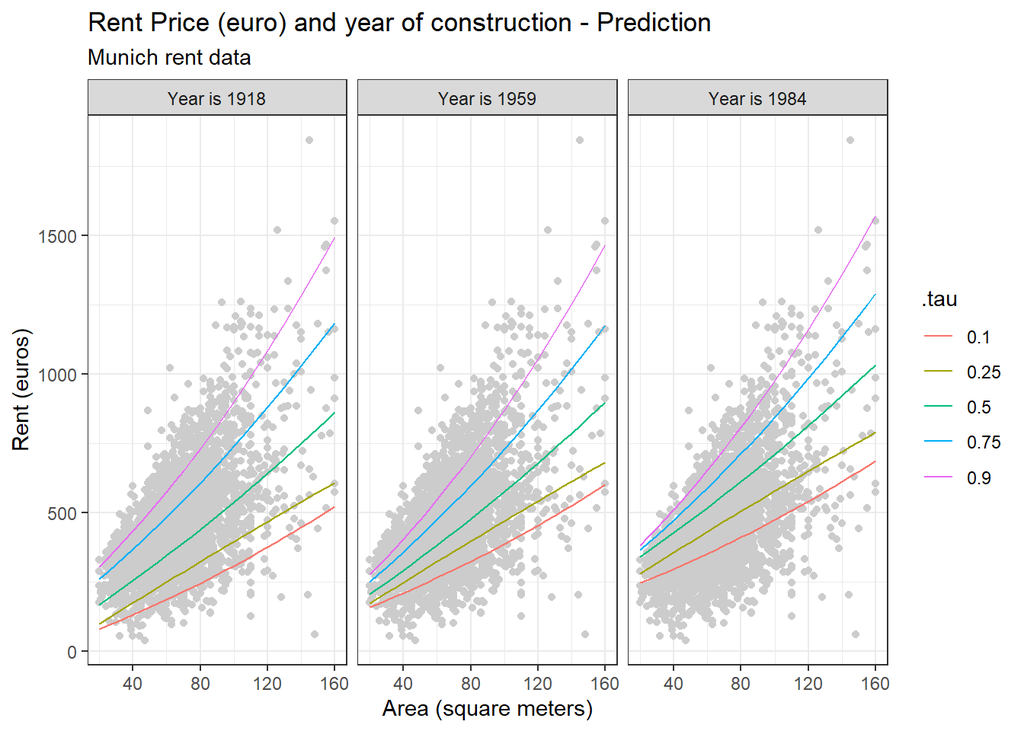

```r
pred_df <- rqfit2_munich %>%
  augment(newdata = expand_grid(area = seq(20,160,by = 5), yearc = c(1918, 1959, 1984))) %>%
  mutate(facyearcc = paste("Year is", yearc))

ggplot(pred_df) +
  geom_point(data = rents, aes(area, rent), col = "grey80") +
  geom_line(aes(x=area, .fitted, col = .tau)) +
  facet_grid(~factor(facyearcc)) +
  labs(title = "Rent Price (euro) and year of construction - Prediction",
       subtitle = "Munich rent data",
       y = "Rent (euros)", x = "Area (square meters)")
```

Let’s do the opposite, let’s look at hte effect of the ‘year’ on rent for different fixed values of the ‘area’.

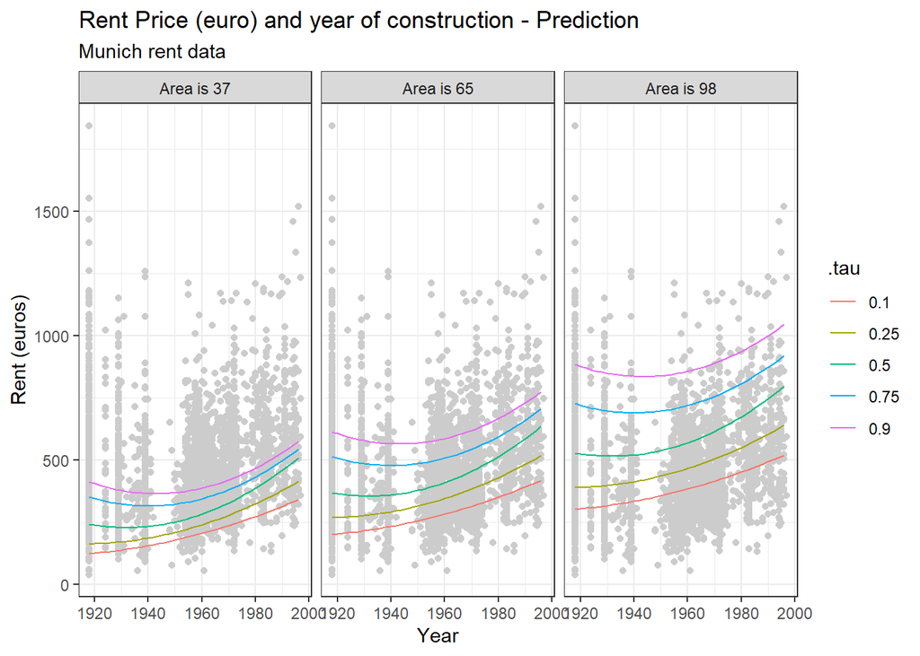

```r
pred_df <- rqfit2_munich %>%
  augment(newdata = expand_grid(area = c(37,65,98), yearc = seq(1918,1997,by = 2))) %>%
  mutate(facarea = paste("Area is", area))

ggplot(pred_df) +
  geom_point(data = rents, aes(yearc, rent), col = "grey80") +
  geom_line(aes(x=yearc, .fitted, col = .tau)) +
  facet_grid(~factor(facarea)) +
  labs(title = "Rent Price (euro) and year of construction - Prediction",
       subtitle = "Munich rent data",
       y = "Rent (euros)", x = "Year")
```

```r
#The variability of the data is much higher when area is larger
```

### Quantile regression - changes in the distribution properties

Once we have the predicted values for different quantiles we can also plot some measure of Scale and Shape as a function of some explanatory variable to assess whether this is changing.

We had defined

$$\begin{equation*}
\begin{array}{ll}
QSC(p|X) & = Q(1-p|X) - Q(p|X) =
(\beta_0^{(1-p)}+\beta_1^{(1-p)}X) - (\beta_0^{(p)}+\beta_1^{(p)}X) =\\
& = (\beta_0^{(1-p)} - \beta_0^{(p)}) + (\beta_1^{(1-p)} -
\beta_1^{(p)})X \end{array}
\end{equation*}$$

$$\begin{equation*}
\begin{array}{ll}
QSK(p|X) & = \frac{ Q(1-p|X) - Q(0.5|X)}{Q(0.5|X) - Q(1|X)}-1 =
\frac{\beta_0^{(1-p)}+\beta_1^{(1-p)}X -
\beta_0^{(0.5)}-\beta_1^{(0.5)}X}{\beta_0^{(0.5)}+\beta_1^{(0.5)}X -
\beta_0^{(p)}-\beta_1^{(p)}X} -1 = \\
& = \frac{(\beta_0^{(1-p)} - \beta_0^{(0.5)})
+(\beta_1^{(1-p)}-\beta_1^{(0.5)})X}{(\beta_0^{(0.5)} - \beta_0^{(p)})
+(\beta_1^{(0.5)}-\beta_1^{(p)})X} -1
\end{array}
\end{equation*}$$

**If the scale is the same $\beta_{1}^{(1-p)}=\beta_{1}^{(p)}$ and QSC(p|X) reduces to a constant.**

**Under symmetry $\beta^{1-p}_1-\beta_{1}^{0.5}=\beta_{1}^{0.5}-\beta^{p}_1$ and $\beta^{1-p}_0-\beta_{0}^{0.5}=\beta_{0}^{0.5}-\beta^{p}_0$ therefore QSK(p|X) reduces to 0.**

```r
library(tidyr)
pred_df <- rqfit2_munich %>%
  augment(newdata = expand_grid(area = seq(20,160,by = 5), yearc = c(1918, 1959, 1984))) %>%
  mutate(taulevel = paste0("tau",.tau)) %>% select(-.tau) %>%
  pivot_wider(names_from = taulevel, values_from = .fitted)
pred_df <- pred_df %>% mutate(QSC25 = tau0.75 - tau0.25,
                              QSK10 = (tau0.9 - tau0.5)/(tau0.5 - tau0.1)-1)
```

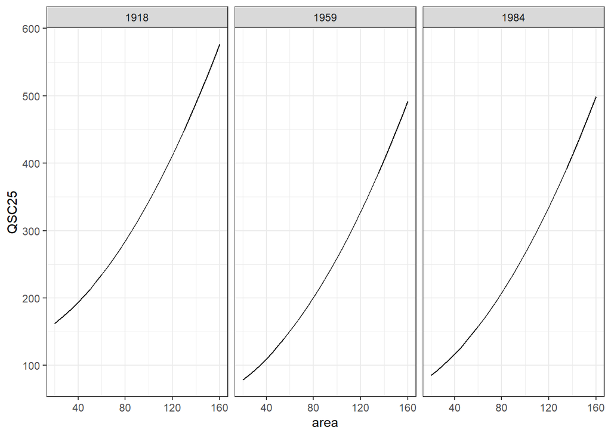

```r
#vedo per esempio che la scale nel 1918 per un income di 40 è 200, mentre per un income di 140 è 500. se la scale aumenta significa che la variabilità è aumentata. inoltre la starting scale (starting variability) nel 1918 era più alta. (heteroskedasticity)

#Scale increases for increasing values of area, but appears to bit lower in 1959.
ggplot(pred_df) +
  geom_line(aes(area,QSC25)) +facet_grid(~factor(yearc))
```

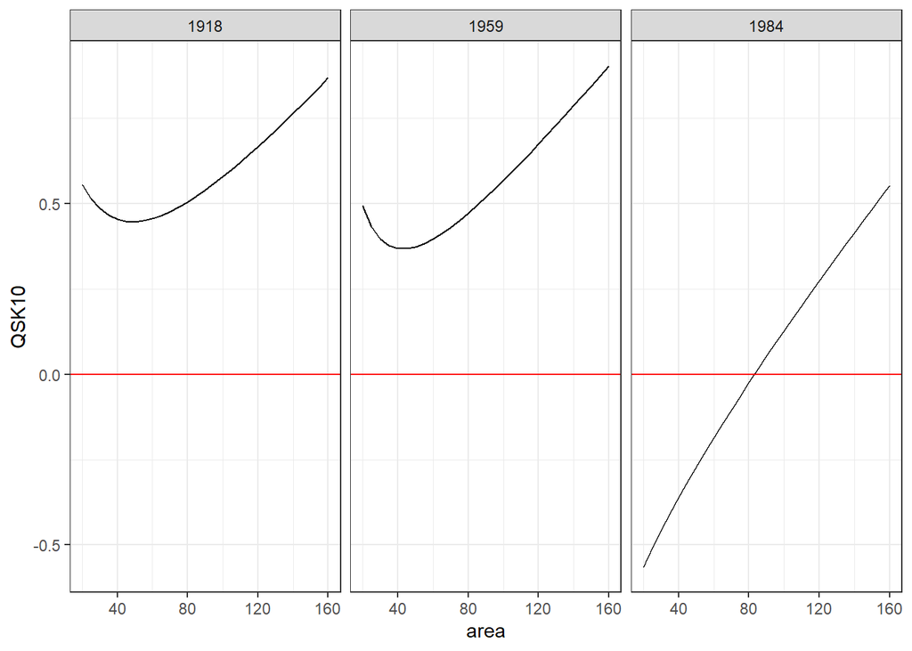

```r
#Skewness has a complex way of changing and it interacts with `yearc`.

ggplot(pred_df) +
  geom_line(aes(area,QSK10)) +
  geom_hline(yintercept = 0, col='red')+
  facet_grid(~factor(yearc))
```

## Exercises

1. Obtain the dataset `bodyfat` in which the weight and the height of a random sample of 255 men are stored:

```r
bodyfat <- read.table("C:/Users/anton/OneDrive/SKOOL/R/BUSINESS ANALYTICS/DATA/bodyfat.txt", header=TRUE)
bodyfat <- bodyfat[,c("Weight","Height")]
```

We wish to construct a regression model in which the Weight of a man is regressed against its Height. Use a quantile regression framework to answer (among others) the following questions:

- What is the effect of Weight on Height: does this appear to change for different quantiles? Compute the estimated coefficients and provide a visual display.

```r
#rq_bodyfat<-rq(Height~Weight, data = bodyfat, tau = c(0.1,0.25,0.5,0.75,0.9))

#coefficients
#rq_bodyfat%>%tidy()

#1 visual display
#ggplot(bodyfat)+
 # geom_point(aes(Weight, Height),col='grey')+
  #geom_quantile(aes(Weight, Height), quantiles=c(0.1,0.25,0.5,0.75,0.9))

#2 visual display
#ggplot()+
 # geom_point(data=bodyfat, aes(Weight, Height), col='grey')+
  #geom_line(data=rq_bodyfat%>%augment(), aes(Weight, .fitted, group=.tau), col='green4')

#is there evidence for change in the effect on different quantiles? no

#p-value >alpha(0.05)
#anova(rq_bodyfat)

#visualization confidence intervals for estimates, different taus;
#plot is consistent with anova test
#rq_bodyfat%>%tidy()%>%filter(term =='Weight')%>%
 # ggplot()+
  #geom_point(aes(tau, estimate), col='grey')+
  #geom_line(aes(tau, estimate), col='lightgrey')+
  #geom_segment(aes(x=tau,xend=tau,
   #            y=conf.low, yend=conf.high))

#It appears that there could be a positive relationship between Weight and Height and there might be  some variability, especially for higher values of weight.

#Nevertheless by carrying an ANOVA test for equality of slopes, there isn't enough evidence to suggest that the slopes are significantly different from each other.

#NO:There is an indication that males with higher weight will display higher height, and the strength of the relationship becomes steeper for higher quantiles.  it means that as you move along the weight axis, the corresponding increase in height becomes more pronounced.

#There seems to be an indication that the variability of the distribution is increasing: the range between the p-th and (1-p)th quantile is increasing for various values of p, especially for p=0.25.
```

- Compute the 95% confidence interval for the slope parameter of the median regression. Also indicate whether there is evidence that its value is null.

```r
#estimate and confidence interval for slope parameter tau=0.5
#rq_bodyfat%>%tidy()%>%filter(tau==0.5, term=='Weight')

#We are 95% confident that the true value of tau=0.5 lies between 0.03996280 and    0.06845537.
#no evidence for nullity of slope  for median regression.
```

- Produce some plots which explore whether the scale or shape of the Weight distribution change as a function of Height.

```r
#summary(bodyfat$Weight)
#summary(bodyfat$Height)

#new fitted dataset; mathematical computation
#index_rq<-rq_bodyfat%>%
#  augment(newdata=expand_grid(Weight=seq(119,262,by=1), Height=seq(64,77, by=1)))%>%
#  mutate(taulevel=paste0('tau',.tau))%>%
 # select(-.tau)%>%
#  pivot_wider(names_from=taulevel, values_from = .fitted)%>%
#  mutate(QSC_025=tau0.75-tau0.25,
 #        QSC_01=tau0.9-tau0.1,
  #       QSK_01=(tau0.9-tau0.5)/(tau0.5-tau0.1)-1,
 #        QSK_025=(tau0.75-tau0.5)/(tau0.5-tau0.25)-1)

#scale: QSC(0.25) conditional to levels of weight
#ggplot(index_rq)+
 # geom_line(aes(Weight,QSC_025))

#scale: QSC(0.1) conditional to levels of weight
#ggplot(index_rq)+
 # geom_line(aes(Weight,QSC_01))
#shape: QSK(0.25) conditional to levels of weight
#ggplot(index_rq)+
 # geom_line(aes(Weight,QSK_025))+
 # geom_hline(yintercept=0, col='red')

#shape: QSK(0.1) conditional to levels of weight
#ggplot(index_rq)+
#  geom_line(aes(Weight,QSK_01))+
#  geom_hline(yintercept=0, col='red')
```

- Is there strong evidence against the distribution of Weight to be different for different levels of Height?
2. Carry out a single predictor quantile regression analysis for the Munich rents dataset investigating the effect of `area` on `rent` and on `rentsq`. Answer questions similar to those presented in Exercise 1.

```r
rents<-read.table("C:/Users/anton/OneDrive/SKOOL/R/BUSINESS ANALYTICS/DATA/rent99.raw", header=TRUE)
```

```r
#model rent~area
area_rqrents<- rq(data=rents, rent~area, tau=c(0.1,0.25,0.5,0.75,0.9))

#model rentsqm~area
area_rqrentsqm<- rq(data=rents, rentsqm~area, tau=c(0.1,0.25,0.5,0.75,0.9))
```

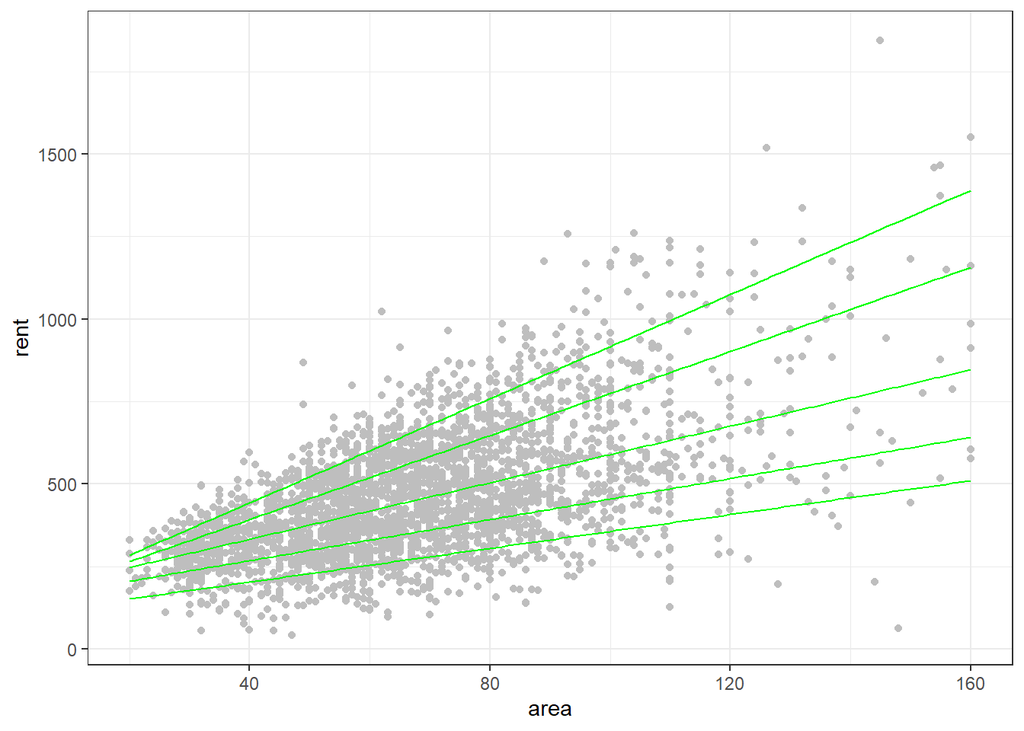

```r
#model rent~area
#display data model rent~area
ggplot()+
  geom_point(data=rents, aes(area, rent), col='grey')+
  geom_line(data=area_rqrents%>%augment(), aes(area, .fitted, group = .tau), col='green')
```

```r
#coefficients
area_rqrents%>%tidy()
```

```
## # A tibble: 10 × 5
##    term        estimate conf.low conf.high   tau
##    <chr>          <dbl>    <dbl>     <dbl> <dbl>
##  1 (Intercept)   100.      82.1     129.    0.1
##  2 area            2.56     2.07      2.83  0.1
##  3 (Intercept)   143.     125.      160.    0.25
##  4 area            3.11     2.80      3.40  0.25
##  5 (Intercept)   161.     148.      179.    0.5
##  6 area            4.28     3.92      4.52  0.5
##  7 (Intercept)   137.     122.      157.    0.75
##  8 area            6.37     6.05      6.65  0.75
##  9 (Intercept)   127.     107.      146.    0.9
## 10 area            7.90     7.55      8.27  0.9
```

```r
#is there evidence for change in the effect on different quantiles? yes
anova(area_rqrents)
```

```
## Quantile Regression Analysis of Deviance Table
##
## Model: rent ~ area
## Joint Test of Equality of Slopes: tau in {  0.1 0.25 0.5 0.75 0.9  }
##
##   Df Resid Df F value    Pr(>F)
## 1  4    15406  123.29 < 2.2e-16 ***
## ---
## Signif. codes:  0 '***' 0.001 '**' 0.01 '*' 0.05 '.' 0.1 ' ' 1
```

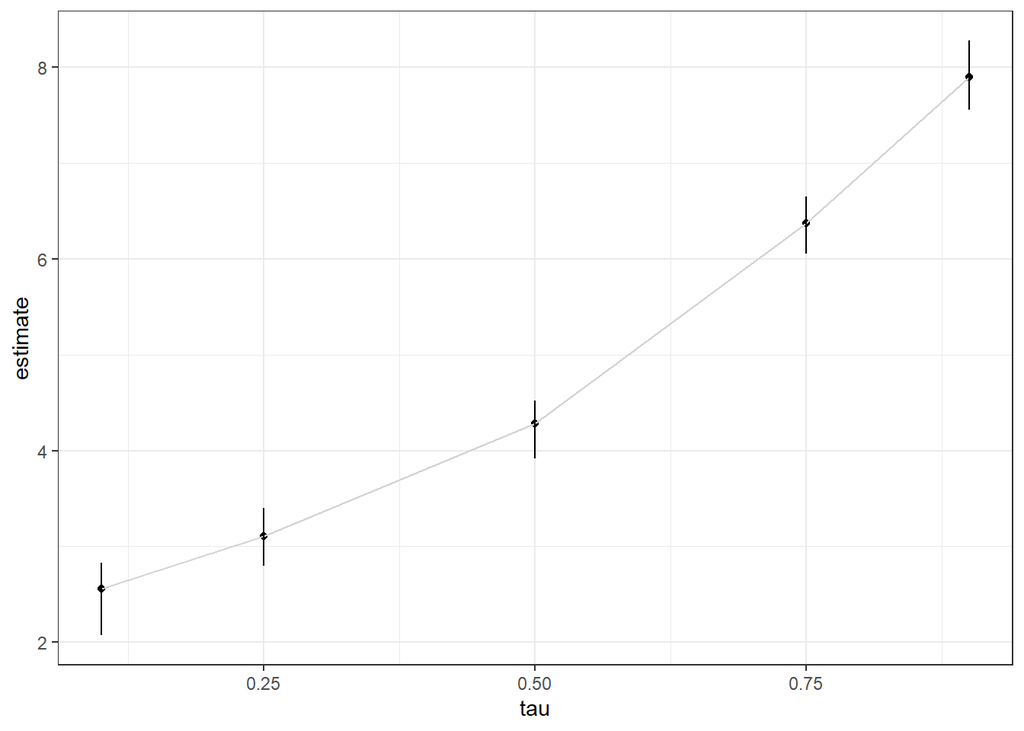

```r
area_rqrents%>%
  tidy()%>%
  filter(term=='area')%>%
  ggplot()+
  geom_point(aes(tau,estimate))+
  geom_line(aes(tau, estimate), col='lightgrey')+
  geom_segment(aes(x=tau, xend=tau,
                   y=conf.low, yend=conf.high))
```

```r
#both the anova test and the plot on the confidence intervals regarding the estimates
#indicate that we can reject the hypothesis of equality of slopes for different taus

#on average the rent increases as the area increases; the effect of area changes on different quantiles,
#the relationship becomes stronger for higher quantiles, the slope is steeper; apartments with higher
#area will pay higher rent

#There seems to be an indication that the variability of the distribution is increasing: the range between the *p*th and #*(1-p)*th quantile is increasing for various values of *p*. the variability we see for rent for lower levels of area is much lower than the variability in rent for higher levels of area. This will be tested with QSC and QSK
```

```r
#Compute the 95\% confidence interval for the slope parameter of the median regression. Also indicate whether there is evidence that its value is null.

#confidence interval for median regressor estimate
area_rqrents%>%tidy()%>%filter(term=='area', tau==0.5)
```

```
## # A tibble: 1 × 5
##   term  estimate conf.low conf.high   tau
##   <chr>    <dbl>    <dbl>     <dbl> <dbl>
## 1 area      4.28     3.92      4.52   0.5
```

```r
#no evidence for nullity
```

```r
#Produce some plots which explore whether the scale or shape of the rent distribution change as a function of area.
summary(rents$rent)
```

```
##    Min. 1st Qu.  Median    Mean 3rd Qu.    Max.
##   40.51  322.03  426.97  459.44  559.36 1843.38
```

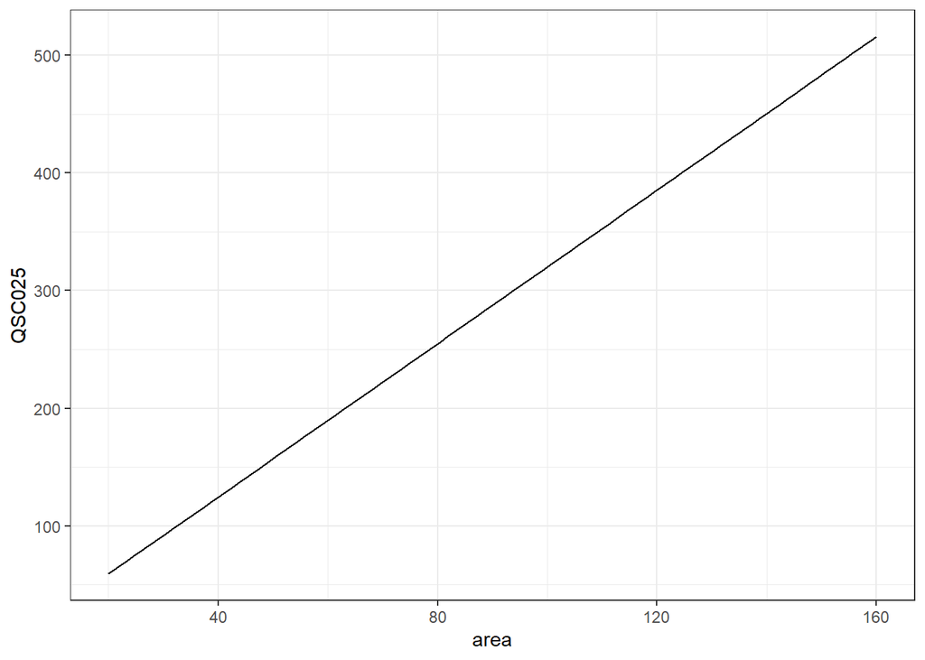

```r
index_arearent<-area_rqrents%>%
  augment(newdata=expand_grid(area=seq(20,160, by=1), rent=seq(51,1844, by=10)))%>%
  mutate(.tau=paste0('tau',.tau))%>%
  pivot_wider(names_from = .tau, values_from = .fitted)%>%
  mutate(QSC025=tau0.75-tau0.25,
         QSC01=tau0.9-tau0.1,
         QSK025=(tau0.75-tau0.5)/(tau0.5-tau0.25)-1,
         QSK01=(tau0.9-tau0.5)/(tau0.5-tau0.1)-1)

#plot QSC(0.25)
ggplot(index_arearent)+
  geom_line(aes(area, QSC025))
```

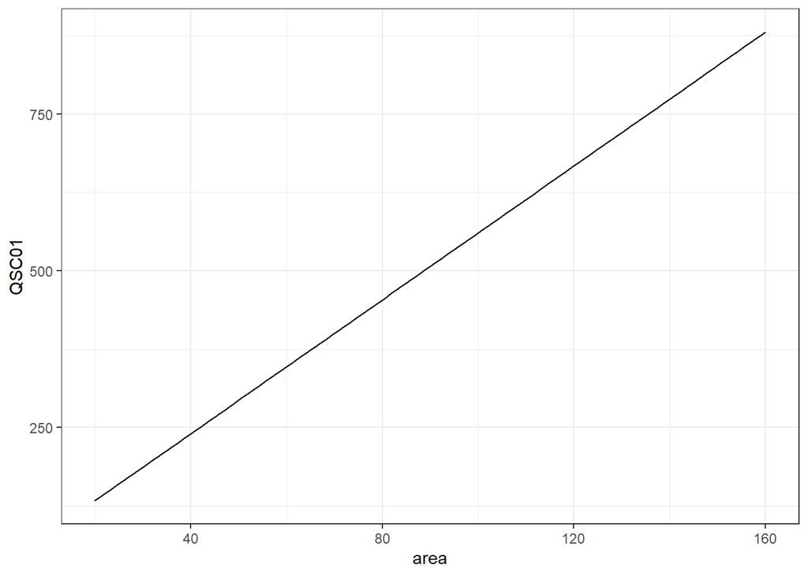

```r
#plot QSC(0.1)
ggplot(index_arearent)+
  geom_line(aes(area, QSC01))
```

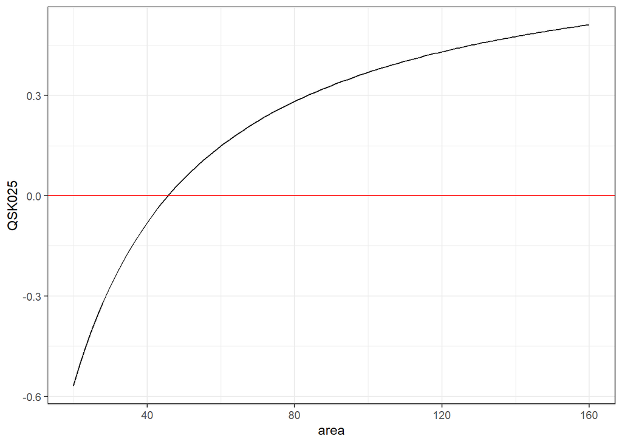

```r
#plot QSK(0.25)
ggplot(index_arearent)+
  geom_line(aes(area, QSK025))+
  geom_hline(yintercept = 0, col='red')
```

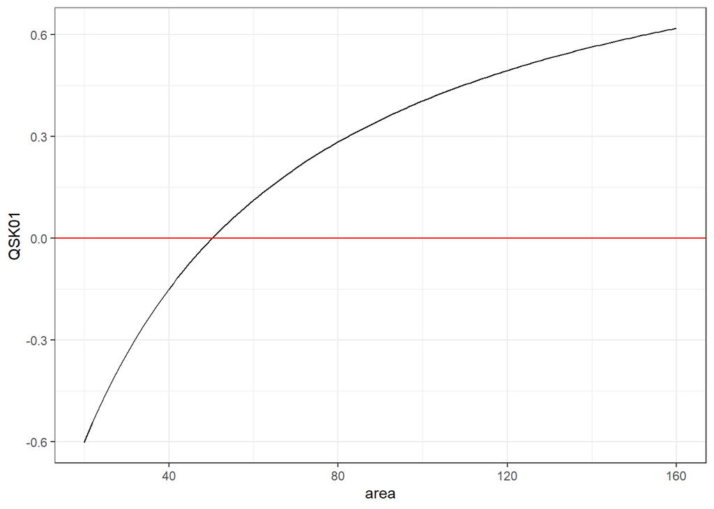

```r
#plot QSK(0.1)
ggplot(index_arearent)+
  geom_line(aes(area, QSK01))+
  geom_hline(yintercept = 0, col='red')
```

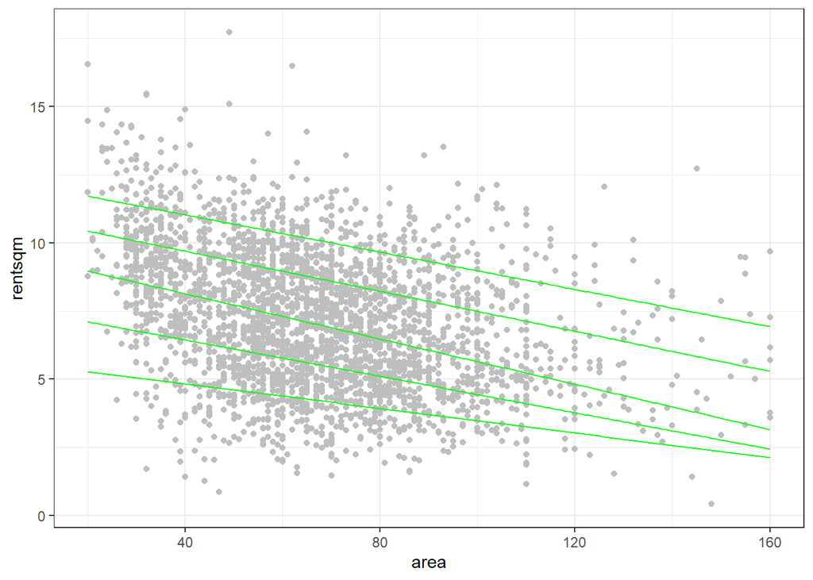

```r
#2 model rnetsqm~area
#display data model rentsqm~area
ggplot()+
  geom_point(data=rents, aes(area, rentsqm), col='grey')+
  geom_line(data=area_rqrentsqm%>%augment(), aes(area, .fitted, group = .tau), col='green')
```

3. Use the `incomeEx` dataset. What is the effect of Age on Income? Is this the same for all quantiles of the distribution? Construct models in which the relationship is allowed to be different depending of the race and education level of the household head. Provide a graphical display which presents the estimated models. Is there enough evidence to indicate that the effect of Age on Income is different for different races/education level? Specify the statistical test that would be carried out.

```r
incomeEx <- read.table('C:/Users/anton/OneDrive/SKOOL/R/BUSINESS ANALYTICS/DATA/incomeSurvey.csv', header=TRUE,sep=",")
```

4. (to be done with pen and paper) Draw the QSK(0.1) and QSC(0.25) function of distributions in which the scale is and skewness increase linearly with a predictor X. Next draw the fitted quantile lines for the (0.1,0.25,0.5,0.75,0.9) quantile of a quantile regression model which would lead to such increases in QSK(0.1) and QSC(0.25). Combine different scenarios with strong or weak increases and decreases of the QSC(0.25) and QSK(0.1) functions.
5. Use the SIPP data: assess how income depends on education at different quantiles (for example 0.1, 0.5 and 0.9): is the effect of education the same for all quantiles? Include the effect of living in a rural setting, both as an additive term as in interaction with education: show the relationship between the different variables (i.e. reproduce the Figures in slide 166 and 167): should one include the rural setting in the estimation? Is the effect comparable for the different quantiles?